# 431 Class 03

Thomas E. Love, Ph.D.

2023-09-05

## Today’s Agenda

- Work in R with a familiar data set (the 15 question “quick survey” from Class 02)
- Open RStudio, load in some data and a template to write Quarto code
  - We’ll do a little typing into the template today, but just a little.
    - We’ll then look at the completed Quarto document.
    - We’ll also inspect and knit the Quarto file after all of the code is included.
  - Then we’ll start over again with the slides.

These slides walk through everything in that Quarto document, and we’ll use the same slides in Class 03 that we use in Class 04, so we can go a bit slowly through things.

## Today’s Files

From our [431-data page](https://github.com/THOMASELOVE/431-data), or our [Class 03 README (data folder)](https://github.com/THOMASELOVE/431-classes-2023/tree/main/class03/data), you should find:

- `431-first-r-template.qmd`
- `quick_survey_2023.csv`

and

- `431-class03-all-code.qmd`

in addition to the usual slide materials.

## Today’s Plan

We’re using Quarto to gather together into a single document:

- the code we build,
- text commenting on and reacting to that code, and
- the output of the analyses we build.

Everything in these slides is also going into our Quarto file.

## Load packages and set theme

```r
library(janitor)
library(patchwork)
library(tidyverse)

theme_set(theme_bw())
knitr::opts_chunk$set(comment = NA)
```

Loading packages in R is like opening up apps on your phone. We need to tell R that, in addition to the base functions available in the software, we also have other functions we want to use.

- Why are we loading these packages, in particular?

## On the tidyverse meta-package

- The most important package is actually a series of packages called the `tidyverse`, which we’ll use in every Quarto file we create this semester.
  - The `tidyverse` includes several packages, all developed (in part) by Hadley Wickham, Chief Scientist at Posit (makers of RStudio).
  - `dplyr` is our main package for data wrangling, cleaning and transformation
  - `ggplot2` is our main visualization package we’ll use for visualization
  - other `tidyverse` packages help import data, work with factors and other common activities.

## More on today’s packages

- The `janitor` package has some tools for examining, cleaning and tabulating data (including `tabyl()` and `clean_names()`) that we’ll use regularly.
- The `patchwork` package will help us show multiple `ggplots` together.
- It’s helpful to load the `tidyverse` package last.

## Today’s Data

Our data come from the Quick 15-item Survey we did in Class 02 ([pdf in Class 02 README](https://github.com/THOMASELOVE/431-classes-2023/blob/main/class02/431_surveyhandout_1perstudent_2023-08-31.pdf)), which we’ve done (in various forms) since 2014.

- A copy of these data (in .csv format) is on our [431-data page](https://github.com/THOMASELOVE/431-data), and also linked on our [Class 03 README](https://github.com/THOMASELOVE/431-classes-2023/tree/main/class03/data).

We’ll tackle several exploratory questions of interest…

## Read in data from `.csv` file

```r
quicksur_raw <-
  read_csv("c03/data/quick_survey_2023.csv", show_col_types = FALSE) |>
  clean_names()
```

- Note the `<-` assignment arrow to create `quicksur_raw`
- Here, we use `read_csv` to read in data from the `c03/data` subfolder of my R project directory which contains the `quick_survey_2023.csv` file from our [431-data page](https://github.com/THOMASELOVE/431-data).
- We use `show_col_types = FALSE` to suppress some unnecessary output describing the column types
- We use `clean_names()` from the janitor package
- Note the use of the pipe `|>` to direct the information flow

## What is the result?

```r
quicksur_raw
```

```
# A tibble: 547 × 23
   student glasses english statsofar love_htcm smoke h_left h_right handedness
     <dbl> <chr>   <chr>       <dbl>     <dbl> <dbl>  <dbl>   <dbl> <chr>
 1  202301 y       <NA>            2       152     1      0      10 1
 2  202302 n       y              NA       152     1     10       0 -1
 3  202303 y       y               4       178     1      0      20 1
 4  202304 n       y               2       183     1      0      20 1
 5  202305 y       y               2       178     1      0      10 1
 6  202306 y       y               6       178     1      5       8 0.23
 7  202307 y       y               5       185     1      4      15 0.58
 8  202308 n       y               5       185     3      5      15 0.5
 9  202309 n       y               4       188     1      0      10 1
10  202310 n       n               3       185     1      2       9 0.64
# ℹ 537 more rows
# ℹ 14 more variables: statfuture <dbl>, haircut <dbl>, lecture <dbl>,
#   alone <dbl>, height_in <dbl>, hand_span <dbl>, favcolor <chr>,
#   lastsleep <dbl>, pulse <dbl>, sex <chr>, ageguess <dbl>, year <dbl>,
#   lovetrueage <dbl>, lovetrueht <dbl>
```

## A more detailed look?

```r
glimpse(quicksur_raw)
```

```
Rows: 547
Columns: 23
$ student     <dbl> 202301, 202302, 202303, 202304, 202305, 202306, 202307, 20…
$ glasses     <chr> "y", "n", "y", "n", "y", "y", "y", "n", "n", "n", "n", "n"…
$ english     <chr> NA, "y", "y", "y", "y", "y", "y", "y", "y", "n", "n", "n",…
$ statsofar   <dbl> 2, NA, 4, 2, 2, 6, 5, 5, 4, 3, 2, 7, 5, 5, 5, 5, 3, 3, 3, …
$ love_htcm   <dbl> 152, 152, 178, 183, 178, 178, 185, 185, 188, 185, 180, 185…
$ smoke       <dbl> 1, 1, 1, 1, 1, 1, 1, 3, 1, 1, 1, 1, 1, 1, 1, 2, 1, 1, 1, 1…
$ h_left      <dbl> 0, 10, 0, 0, 0, 5, 4, 5, 0, 2, 0, 2, 10, 0, 0, 12, 0, 7, 1…
$ h_right     <dbl> 10, 0, 20, 20, 10, 8, 15, 15, 10, 9, 10, 9, 0, 10, 18, 4, …
$ handedness  <chr> "1", "-1", "1", "1", "1", "0.23", "0.58", "0.5", "1", "0.6…
$ statfuture  <dbl> 7, 7, 6, 5, 6, 7, 7, 7, 6, 5, 7, 5, 7, 6, 7, 6, 5, 6, 6, 7…
$ haircut     <dbl> 0, 10, 45, 200, 40, 35, 70, 65, 40, 0, 12, 0, 60, 80, 75, …
$ lecture     <dbl> 3, 3, 2, 3, 2, 3, 4, 3, 4, 2, 5, 2, 4, 4, 4, 3, 3, 3, 4, 4…
$ alone       <dbl> 3, 3, 2, 4, 2, 3, 4, 4, 3, 2, 5, 2, 4, 4, 4, 3, 4, 4, 3, 3…
$ height_in   <dbl> 61.0, 63.0, 61.0, 64.0, 62.0, 73.0, 74.0, 66.0, 71.0, 60.0…
$ hand_span   <dbl> 19.5, 19.0, 20.0, 19.0, 18.5, 26.0, 25.5, 21.0, 15.0, 17.5…
$ favcolor    <chr> "sky blue", "black", "purple", "blue", "purple", "blue", "…
$ lastsleep   <dbl> 5.0, 6.0, 8.5, 6.0, 9.0, 6.0, 6.0, 7.0, 6.0, 8.0, 9.5, 8.0…
$ pulse       <dbl> NA, NA, 104, 92, 88, 54, 72, 76, 78, 68, 68, 68, 88, 60, 7…
$ sex         <chr> NA, NA, NA, NA, NA, NA, NA, NA, NA, NA, NA, NA, NA, NA, NA…
$ ageguess    <dbl> NA, NA, NA, NA, NA, NA, NA, NA, NA, NA, NA, NA, NA, NA, NA…
$ year        <dbl> 2023, 2023, 2023, 2023, 2023, 2023, 2023, 2023, 2023, 2023…
$ lovetrueage <dbl> 56.5, 56.5, 56.5, 56.5, 56.5, 56.5, 56.5, 56.5, 56.5, 56.5…
$ lovetrueht  <dbl> 189, 189, 189, 189, 189, 189, 189, 189, 189, 189, 189, 189…
```

## Counting Categories

```r
quicksur_raw |> count(glasses)
```

```
# A tibble: 3 × 2
  glasses     n
  <chr>   <int>
1 n         100
2 y         193
3 <NA>      254
```

```r
quicksur_raw |> count(glasses, english)
```

```
# A tibble: 9 × 3
  glasses english     n
  <chr>   <chr>   <int>
1 n       n          27
2 n       y          72
3 n       <NA>        1
4 y       n          41
5 y       y         150
6 y       <NA>        2
7 <NA>    n          47
8 <NA>    y         205
9 <NA>    <NA>        2
```

## Favorite Color in 2023?

```r
quicksur_raw |>
    filter(year == "2023") |>
    tabyl(favcolor) |>
    adorn_pct_formatting()
```

```
   favcolor  n percent
 aquamarine  1    1.9%
      black  2    3.8%
       blue 21   39.6%
       gray  1    1.9%
      green  5    9.4%
 light blue  1    1.9%
     purple  9   17.0%
        red  5    9.4%
 royal blue  1    1.9%
   sky blue  1    1.9%
       teal  1    1.9%
      white  2    3.8%
     yellow  3    5.7%
```

## Using `summary()` on Quantities

```r
quicksur_raw |>
  select(love_htcm, haircut, height_in, lastsleep) |>
  summary()
```

```
   love_htcm        haircut         height_in      lastsleep
 Min.   :152.0   Min.   :  0.00   Min.   :57.0   Min.   : 2.000
 1st Qu.:178.0   1st Qu.: 13.25   1st Qu.:64.0   1st Qu.: 6.000
 Median :183.0   Median : 22.00   Median :67.0   Median : 7.000
 Mean   :182.1   Mean   : 30.84   Mean   :67.2   Mean   : 6.935
 3rd Qu.:188.0   3rd Qu.: 40.00   3rd Qu.:70.0   3rd Qu.: 8.000
 Max.   :193.0   Max.   :250.00   Max.   :77.5   Max.   :12.000
 NA's   :385     NA's   :9        NA's   :7      NA's   :6
```

- Numerical summaries (five quantiles, plus the mean) for:
  - your guess of my height (in cm), last haircut price ($), your height (in inches), and last night’s hours of sleep
- How many observations are available for these measures?

## Five Questions of Interest

1. What is the distribution of pulse rates among students in 431 since 2014?
2. Does the distribution of student heights change materially over time?
3. Is the Normal distribution a good model for our data?
4. Do taller people appear to have paid less for their most recent haircut?
5. Do students have a more substantial tobacco history if they prefer to speak English or a language other than English?

# Manage the data into `qsdat`

## Variables we’ll look at closely today

To address our Questions of Interest, we need these seven variables in our analytic data frame (tibble.)

- `student`: student identification (numerical code)
- `year`: indicates year when survey was taken (August)
- `english`: y = prefers to speak English, else n
- `smoke`: 1 = never smoker, 2 = quit, 3 = current
- `pulse`: pulse rate (beats per minute)
- `height_in`: student’s height (in inches)
- `haircut`: price of student’s last haircut (in $)

## Select our variables

```r
qsdat <- quicksur_raw |>
    select(student, year, english, smoke,
           pulse, height_in, haircut)
```

- The `select()` function chooses the variables (columns) we want to keep in our new tibble called `qsdat`.
- What should the result of this code look like?

## What do we have now?

```r
qsdat
```

```
# A tibble: 547 × 7
   student  year english smoke pulse height_in haircut
     <dbl> <dbl> <chr>   <dbl> <dbl>     <dbl>   <dbl>
 1  202301  2023 <NA>        1    NA        61       0
 2  202302  2023 y           1    NA        63      10
 3  202303  2023 y           1   104        61      45
 4  202304  2023 y           1    92        64     200
 5  202305  2023 y           1    88        62      40
 6  202306  2023 y           1    54        73      35
 7  202307  2023 y           1    72        74      70
 8  202308  2023 y           3    76        66      65
 9  202309  2023 y           1    78        71      40
10  202310  2023 n           1    68        60       0
# ℹ 537 more rows
```

## Initial Numeric Summaries

- Is everything the “type” of variable it should be?
- Are we getting the summaries we want?

```r
summary(qsdat)
```

```
    student            year        english              smoke
 Min.   :201401   Min.   :2014   Length:547         Min.   :1.00
 1st Qu.:201647   1st Qu.:2016   Class :character   1st Qu.:1.00
 Median :201920   Median :2019   Mode  :character   Median :1.00
 Mean   :201894   Mean   :2019                      Mean   :1.09
 3rd Qu.:202129   3rd Qu.:2021                      3rd Qu.:1.00
 Max.   :202353   Max.   :2023                      Max.   :3.00
                                                    NA's   :2
     pulse          height_in       haircut
 Min.   : 30.00   Min.   :57.0   Min.   :  0.00
 1st Qu.: 66.00   1st Qu.:64.0   1st Qu.: 13.25
 Median : 72.00   Median :67.0   Median : 22.00
 Mean   : 74.07   Mean   :67.2   Mean   : 30.84
 3rd Qu.: 80.75   3rd Qu.:70.0   3rd Qu.: 40.00
 Max.   :112.00   Max.   :77.5   Max.   :250.00
 NA's   :77       NA's   :7      NA's   :9
```

## What should we be seeing?

- Categorical variables should list the categories, with associated counts.
  - To accomplish this, the variable needs to be represented in R with a `factor`, rather than as a `character` or `numeric` variable.
- Quantitative variables should show the minimum, median, mean, maximum, etc.

```r
names(qsdat)
```

```
[1] "student"   "year"      "english"   "smoke"     "pulse"     "height_in"
[7] "haircut"
```

## Change categorical variables to factors

We want the `year` and `smoke` information treated as categorical, rather than as quantitative, and the `english` information as a factor, too. Also, do we want to summarize the student ID codes?

- We use the `mutate()` function to help with this.

```r
qsdat <- qsdat |>
    mutate(year = as_factor(year),
           smoke = as_factor(smoke),
           english = as_factor(english),
           student = as.character(student))
```

- Note that it’s `as_factor()` but `as.character()`. Sigh.

## Next step: Recheck the summaries and do range checks

- Do these summaries make sense?
- Are the minimum and maximum values appropriate?
- How much missingness are we to deal with?

## Now, how’s our summary?

```r
summary(qsdat)
```

```
   student               year     english     smoke         pulse
 Length:547         2020   : 67   y   :427   1   :505   Min.   : 30.00
 Class :character   2016   : 64   n   :115   2   : 31   1st Qu.: 66.00
 Mode  :character   2019   : 61   NA's:  5   3   :  9   Median : 72.00
                    2021   : 58              NA's:  2   Mean   : 74.07
                    2022   : 54                         3rd Qu.: 80.75
                    2023   : 53                         Max.   :112.00
                    (Other):190                         NA's   :77
   height_in       haircut
 Min.   :57.0   Min.   :  0.00
 1st Qu.:64.0   1st Qu.: 13.25
 Median :67.0   Median : 22.00
 Mean   :67.2   Mean   : 30.84
 3rd Qu.:70.0   3rd Qu.: 40.00
 Max.   :77.5   Max.   :250.00
 NA's   :7      NA's   :9
```

- Some things to look for appear on the next slide.

## What to look for…

- Are we getting counts for all variables that are categorical?
  - Do the category levels make sense?
- Are we getting means and medians for all variables that are quantities?
  - Do the minimum and maximum values make sense for each of these quantities?
- Which variables have missing data, as indicated by `NA's`?

## The summary for `year` is an issue

- Just to fill in the gap left by the `summary()` result, how many students responded each year?

```r
qsdat |> tabyl(year) |> adorn_totals() |> adorn_pct_formatting()
```

```
  year   n percent
  2014  42    7.7%
  2015  49    9.0%
  2016  64   11.7%
  2017  48    8.8%
  2018  51    9.3%
  2019  61   11.2%
  2020  67   12.2%
  2021  58   10.6%
  2022  54    9.9%
  2023  53    9.7%
 Total 547  100.0%
```

# Question 1 (Distribution of Student Pulse Rates)

## Histogram, first try

- What is the distribution of student `pulse` rates?

```r
ggplot(data = qsdat, aes(x = pulse)) +
    geom_histogram(bins = 30, fill = "royalblue",  col = "seagreen1")
```

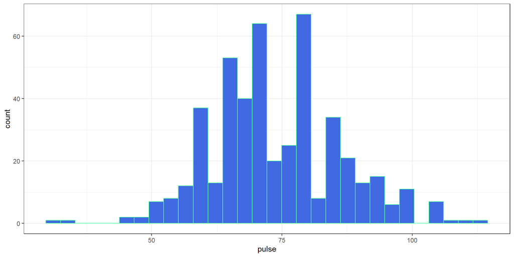

## Describing the Pulse Rates

How might we describe this distribution?

- What is the center?
- How much of a range around that center do we see? How spread out are the data?
- What is the shape of this distribution?
  - Is it symmetric, or is it skewed to the left or to the right?

(Histogram is replotted on the next slide)

## Histogram, first try again

```r
ggplot(data = qsdat, aes(x = pulse)) +
    geom_histogram(bins = 30, fill = "royalblue", col = "seagreen1")
```

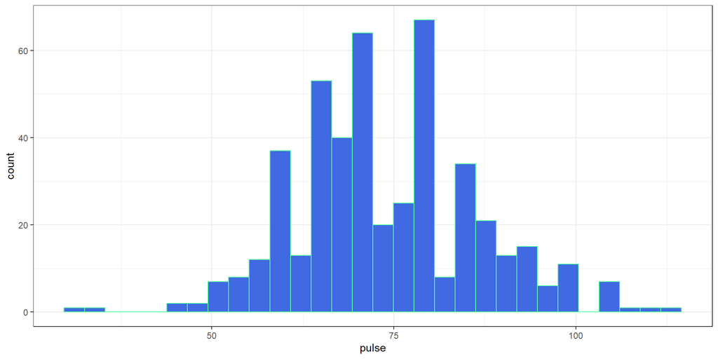

## Fundamental Numerical Summaries

```r
qsdat |> select(pulse) |> summary()
```

```
     pulse
 Min.   : 30.00
 1st Qu.: 66.00
 Median : 72.00
 Mean   : 74.07
 3rd Qu.: 80.75
 Max.   :112.00
 NA's   :77
```

- How do the summary statistics help us describe the data?
- Do the values make sense to you?

```r
mosaic::favstats(~ pulse, data = qsdat)
```

```
 min Q1 median    Q3 max     mean       sd   n missing
  30 66     72 80.75 112 74.06809 12.46366 470      77
```

## Histogram, version 2

```r
dat1 <- qsdat |>
  filter(complete.cases(pulse))

ggplot(data = dat1, aes(x = pulse)) +
    geom_histogram(fill = "seagreen", col = "white", bins = 20) +
    labs(title = "Pulse Rates of Dr. Love's students",
         subtitle = "2014 - 2023",
         y = "Number of Students",
         x = "Pulse Rate (beats per minute)")
```

- How did we deal with missing data?
- How did we add axis labels and titles to the plot?
- What is the distinction between `fill` and `col`?
- How many bins should we use?

## Histogram, version 2

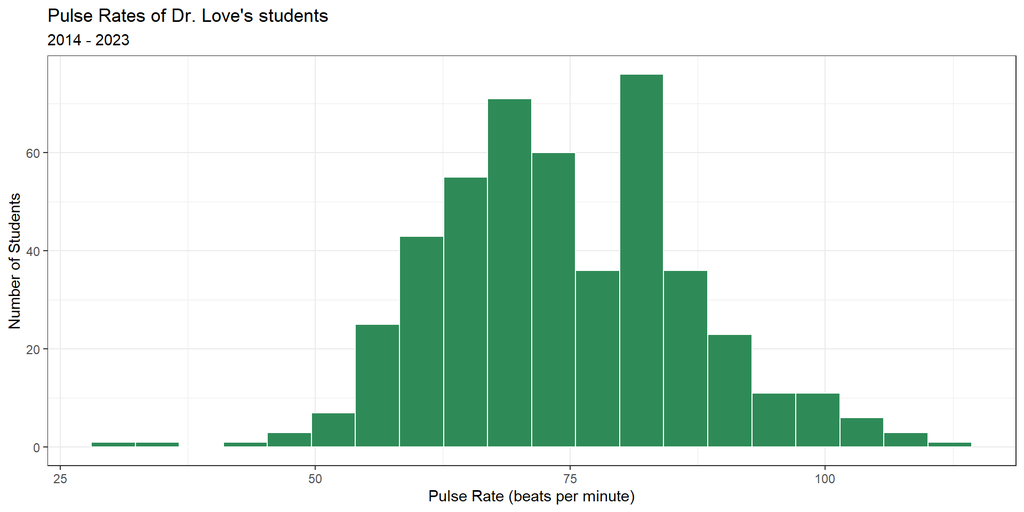

# Question 2 (Student Heights over Time)

## Yearly Five-Number Summaries

```r
qsdat |>
    filter(complete.cases(height_in)) |>
    group_by(year) |>
    summarize(n = n(), min = min(height_in), q25 = quantile(height_in, 0.25),
              median = median(height_in), q75 = quantile(height_in, 0.75),
              max = max(height_in))
```

- What should this produce? (Results on next slide)

## Yearly Five-Number Summaries

```
# A tibble: 10 × 7
   year      n   min   q25 median   q75   max
   <fct> <int> <dbl> <dbl>  <dbl> <dbl> <dbl>
 1 2014     40    60  64.8   68    71    73
 2 2015     49    61  65     68    70    74
 3 2016     64    60  64     67    70    76
 4 2017     48    62  65     67    69    77
 5 2018     51    60  63     66    70    73
 6 2019     60    57  65     68    70    77.5
 7 2020     66    59  63     66    69.8  76
 8 2021     55    60  64.5   67.5  71    77.5
 9 2022     54    59  66     68.5  70.4  76
10 2023     53    60  64     65    69    77
```

- Does the distribution of heights change materially in 2014-2023?
- What are these summaries, specifically?

## Five-Number Summary

- Key summaries based on percentiles / quantiles
  - minimum = 0th, maximum = 100th, median = 50th
  - quartiles (25th, 50th and 75th percentiles)
  - Range is maximum - minimum
  - IQR (inter-quartile range) is 75th - 25th percentile
- These summaries are generally more resistant to outliers than mean, standard deviation
- Form the elements of a boxplot (box-and-whisker plot)

## Comparison Boxplot of Heights by Year

```r
dat2 <- qsdat |>
    filter(complete.cases(height_in))

ggplot(data = dat2, aes(x = year, y = height_in)) +
    geom_boxplot() +
    labs(title = "Heights of Dr. Love's students, by year",
         subtitle = "2014 - 2023", x = "Year", y = "Height (in inches)")
```

- How did we deal with missing data here?

## Comparison Boxplot of Heights by Year

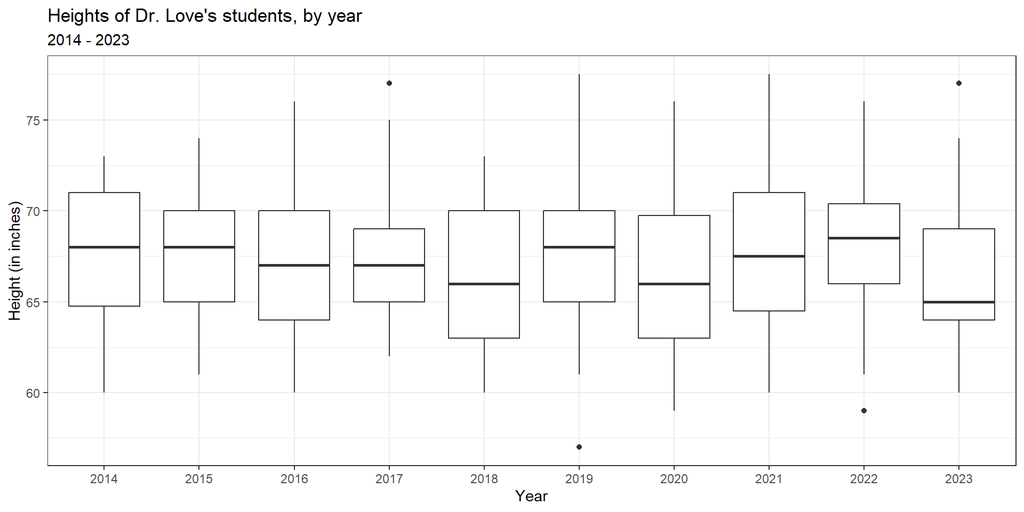

## Thinking about the Boxplot

- Box covers the middle half of the data (25th and 75th percentiles), and the solid line indicates the median
- Whiskers extend from the quartiles to the most extreme values that are not judged by **Tukey’s** “fences” method to be candidate outliers
  - Fences are drawn at 25th percentile - 1.5 IQR and 75th percentile + 1.5 IQR
- Are any values candidate outliers by this method? For which years?
- Was it important to change `year` to a factor earlier?

## Adding a Violin to the Boxplot

- When we’d like to better understand the shape of a distribution, we can amplify the boxplot.

```r
dat2 <- qsdat |>
    filter(complete.cases(height_in))

ggplot(data = dat2, aes(x = year, y = height_in)) +
    geom_violin() +
    geom_boxplot(aes(fill = year), width = 0.3) +
    guides(fill = "none") +
    scale_fill_viridis_d() +
    labs(title = "Heights of Dr. Love's students, by year",
         subtitle = "2014 - 2023", x = "Year", y = "Height (in inches)")
```

## Adding a Violin to the Boxplot

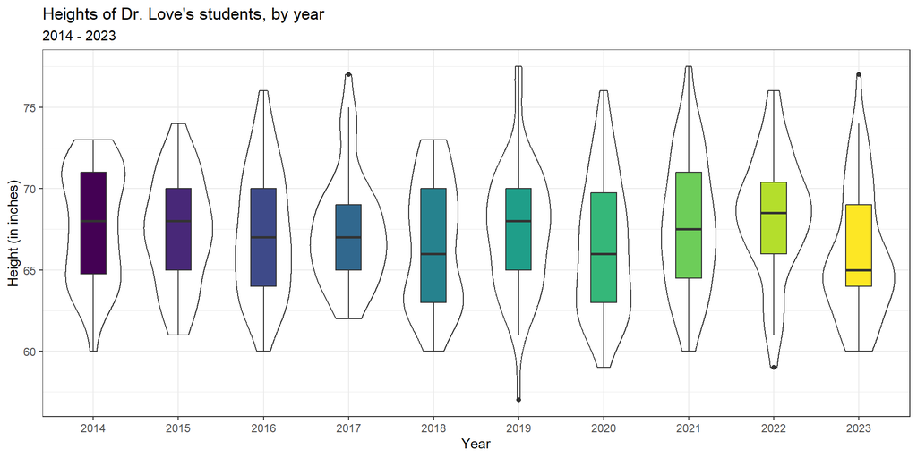

## Thinking About our Boxplot with Violin

- How did we change the boxplot when we added the violin?
- What would happen if we added the boxplot first and the violin second?
- What does `guides(fill = "none")` do?
- What does `scale_fill_viridis_d()` do?

## Table of Means and Standard Deviations

```r
qsdat |>
    filter(complete.cases(height_in)) |>
    group_by(year) |>
    summarize(n = n(), mean = mean(height_in), sd = sd(height_in))
```

```
# A tibble: 10 × 4
   year      n  mean    sd
   <fct> <int> <dbl> <dbl>
 1 2014     40  67.8  3.46
 2 2015     49  67.3  3.32
 3 2016     64  67.2  3.86
 4 2017     48  67.4  3.46
 5 2018     51  66.5  3.81
 6 2019     60  67.4  3.83
 7 2020     66  66.4  4.09
 8 2021     55  67.8  4.13
 9 2022     54  68.4  3.74
10 2023     53  66.0  4.00
```

## So, what do we think?

Are the distributions of student height very different from year to year?

- What output that I’ve provided here can help answer this question?
- What other things would you like to see?

# Question 3 Can we assume that the Mean and SD are sensible summaries?

## A Normal distribution (bell-shaped curve)

- A Normal distribution is completely specified by its mean and standard deviation. The “bell shape” doesn’t change.

## Summarizing Quantitative Data

If the data followed a Normal model,

- we would be justified in using the sample **mean** to describe the center, and
- in using the sample **standard deviation** to describe the spread (variation.)

But it is often the case that these measures aren’t robust enough, because the data show meaningful skew (asymmetry), or the data have lighter or heavier tails than a Normal model would predict.

## The Empirical Rule for Approximately Normal Distributions

If the data followed a Normal distribution,

- approximately 68% of the data would be within 1 SD of the mean,
- approximately 95% of the data would be within 2 SD of the mean, while
- essentially all (99.7%) of the data would be within 3 SD of the mean.

## Empirical Rule & 2023 Student Heights

In 2023, we had 53 students whose `height_in` was available, with mean 66.0 inches (167.6 cm) and standard deviation 4 inches (10.2 cm).

What do the histogram (next slide) and boxplot (seen earlier) suggest about whether a Normal model with this mean and standard deviation would hold well for these 53 student heights?

## Histogram of 2023 Student Heights

```r
dat3 <- qsdat |>
  filter(complete.cases(height_in)) |>
  filter(year == "2023")

ggplot(data = dat3, aes(x = height_in)) +
    geom_histogram(fill = "salmon", col = "white", binwidth = 1) +
    labs(title = "Heights of Dr. Love's students",
         subtitle = "2023 (n = 53 students with height data)",
         y = "Number of Students", x = "Height (inches)")
```

- How did we use the two `filter()` statements?
- Why might I have changed from specifying `bins` to `binwidth` here?

## Histogram of 2023 Student Heights

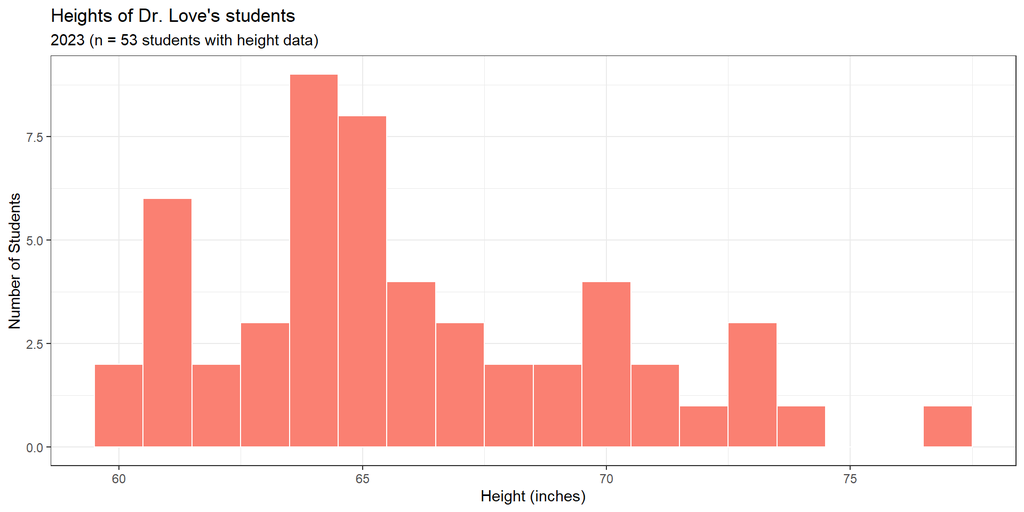

## Checking the 1-SD Empirical Rule

- Of the 53 students in 2023 with heights, how many were within 1 SD of the mean?
  - Mean = 66, SD = 4.
  - 66 - 4 = 62 inches and 66 + 4 = 70 inches

```r
qsdat |> filter(complete.cases(height_in)) |>
    filter(year == "2023") |>
    count(height_in >= 62 & height_in <= 70)
```

```
# A tibble: 2 × 2
  `height_in >= 62 & height_in <= 70`     n
  <lgl>                               <int>
1 FALSE                                  16
2 TRUE                                   37
```

```r
37/(37+16)
```

```
[1] 0.6981132
```

## 2-SD Empirical Rule

- How many of the 53 `height_in` values gathered in 2023 were between 66 - 2(4) = 58.0 and 66 + 2(4) = 74 inches?

```r
qsdat |> filter(complete.cases(height_in)) |>
    filter(year == "2023") |>
    count(height_in >= 58 & height_in <= 74)
```

```
# A tibble: 2 × 2
  `height_in >= 58 & height_in <= 74`     n
  <lgl>                               <int>
1 FALSE                                   1
2 TRUE                                   52
```

```r
52/(52+1)
```

```
[1] 0.9811321
```

## 3-SD Empirical Rule

- How many of the 53 `height_in` values gathered in 2023 were between 66 - 3(4) = 54 and 66 + 3(4) = 78 inches?

```r
qsdat |> filter(complete.cases(height_in)) |>
    filter(year == "2023") |>
    count(height_in >= 54 & height_in <= 78)
```

```
# A tibble: 1 × 2
  `height_in >= 54 & height_in <= 78`     n
  <lgl>                               <int>
1 TRUE                                   53
```

```r
53/(53+0)
```

```
[1] 1
```

## Empirical Rule Table for 2023 data

- $\bar{x}$ = sample mean, $s$ = sample SD
- For `height_in`: $n$ = 53 with data, $\bar{x} = 66, s = 4$
- For `pulse`: $n$ = 51 with data, $\bar{x} = 78.2, s = 12.7$

| Range | “Normal” | `height_in` | `pulse` |
| --- | --- | --- | --- |
| $\bar{x} \pm s$ | ~68% | $\frac{37}{53}$ = 69.8% | $\frac{40}{51}$ = 78.4% |
| $\bar{x} \pm 2\times s$ | ~95% | $\frac{52}{53}$ = 98.1% | $\frac{47}{51}$ = 92.2% |
| $\bar{x} \pm 3\times s$ | ~99.7% | $\frac{53}{53}$ = 100% | $\frac{51}{51}$ = 100% |

## Boxplots of Height and of Pulse Rate

```r
dat4 <- qsdat |> filter(complete.cases(height_in), year == "2023")

p4 <- ggplot(data = dat4, aes(x = "height (inches)", y = height_in)) +
  geom_violin() + geom_boxplot(width = 0.3, fill = "tomato") +
  labs(title = "Boxplot of 2023 Student Heights", x = "")

dat5 <- qsdat |> filter(complete.cases(pulse), year == "2023")

p5 <- ggplot(data = dat5, aes(x = "pulse rate (beats/minute)", y = pulse)) +
  geom_violin() + geom_boxplot(width = 0.3, fill = "dodgerblue") +
  labs(title = "Boxplot of 2023 Pulse Rates", x = "")

p4 + p5 +
  plot_annotation(title = "2023 Quick Survey Data")
```

- What is `width = 0.3` doing? How about the `x` options?
- What am I doing with `p4 + p5 + plot_annotation`?
- What should this look like?

## Boxplots of Height and of Pulse Rate

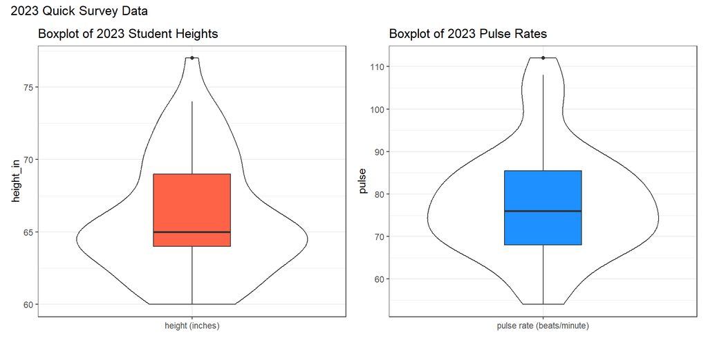

## Normality and Mean/SD as summaries

If the data are approximately Normally distributed (like `height_in` and `pulse`) we can safely use the sample mean and standard deviation as summaries. If not “Normal”, then …

- The median is a more robust summary of the center.
- For spread, we often use the 25th and 75th percentiles.

```r
dat3 <- qsdat |> filter(year == "2023")
mosaic::favstats(~ height_in, data = dat3)
```

```
 min Q1 median Q3 max     mean       sd  n missing
  60 64     65 69  77 66.00943 3.998185 53       0
```

```r
mosaic::favstats(~ pulse, data = dat3)
```

```
 min Q1 median   Q3 max     mean       sd  n missing
  54 68     76 85.5 112 78.15686 12.73165 51       2
```

## A new quantitative variable

Let’s look at haircut prices, across all years.

```r
mosaic::favstats(~ haircut, data = qsdat)
```

```
 min    Q1 median Q3 max     mean       sd   n missing
   0 13.25     22 40 250 30.84015 32.68273 538       9
```

Does it seem like the Normal model will be a good fit for these prices?

- Why or why not?
- What more information do you need to make a decision?

## 2023 Haircut Prices

- Unsorted
- Sorted
- Counts

```r
qsdat |> filter(year == "2023") |>
  select(haircut) |>
  as.vector() ## just to print it here horizontally
```

```
$haircut
 [1]   0.0  10.0  45.0 200.0  40.0  35.0  70.0  65.0  40.0   0.0  12.0   0.0
[13]  60.0  80.0  75.0  30.0  15.0   0.0   0.0  26.0 100.0  65.0  20.0   0.0
[25]  32.0  20.0  48.0   0.0  30.0   0.0 180.0  35.0  20.0   5.0   0.0  35.0
[37]  45.0   0.0 150.0  14.0   0.0   7.5   0.0  20.0  57.0  22.0  50.0  30.0
[49]  30.0  35.0  20.0  50.0  35.0
```

```r
qsdat |> filter(year == "2023") |>
  select(haircut) |> arrange(haircut) |>
  as.vector() ## just to print it here horizontally
```

```
$haircut
 [1]   0.0   0.0   0.0   0.0   0.0   0.0   0.0   0.0   0.0   0.0   0.0   0.0
[13]   5.0   7.5  10.0  12.0  14.0  15.0  20.0  20.0  20.0  20.0  20.0  22.0
[25]  26.0  30.0  30.0  30.0  30.0  32.0  35.0  35.0  35.0  35.0  35.0  40.0
[37]  40.0  45.0  45.0  48.0  50.0  50.0  57.0  60.0  65.0  65.0  70.0  75.0
[49]  80.0 100.0 150.0 180.0 200.0
```

```r
qsdat |> filter(year == "2023") |>
  count(haircut)
```

```
# A tibble: 27 × 2
   haircut     n
     <dbl> <int>
 1     0      12
 2     5       1
 3     7.5     1
 4    10       1
 5    12       1
 6    14       1
 7    15       1
 8    20       5
 9    22       1
10    26       1
# ℹ 17 more rows
```

## 2023 Haircut Prices, tabulated

```r
qsdat |> filter(year == "2023") |> tabyl(haircut) |> adorn_pct_formatting()
```

```
 haircut  n percent
     0.0 12   22.6%
     5.0  1    1.9%
     7.5  1    1.9%
    10.0  1    1.9%
    12.0  1    1.9%
    14.0  1    1.9%
    15.0  1    1.9%
    20.0  5    9.4%
    22.0  1    1.9%
    26.0  1    1.9%
    30.0  4    7.5%
    32.0  1    1.9%
    35.0  5    9.4%
    40.0  2    3.8%
    45.0  2    3.8%
    48.0  1    1.9%
    50.0  2    3.8%
    57.0  1    1.9%
    60.0  1    1.9%
    65.0  2    3.8%
    70.0  1    1.9%
    75.0  1    1.9%
    80.0  1    1.9%
   100.0  1    1.9%
   150.0  1    1.9%
   180.0  1    1.9%
   200.0  1    1.9%
```

## Normality of Haircut prices?

```r
dat6 <- qsdat |> filter(complete.cases(haircut))

p6a <- ggplot(data = dat6, aes(x = haircut)) +
  geom_histogram(binwidth = 5, fill = "purple", col = "white") +
  labs(x = "Haircut Price (in $)")

p6b <- ggplot(data = dat6, aes(x = haircut, y = "Price")) +
  geom_violin(fill = "plum") + geom_boxplot(width = 0.3) +
  labs(y = "", x = "Haircut Prices in $")

p6a + p6b +
  plot_annotation(
    title = "Histogram and Boxplot of Haircut Prices",
    subtitle = "2014-2023 Students of Dr. Love in 431")
```

- Do you think that the distribution of these prices follows a Normal model?

## Normality of Haircut prices?

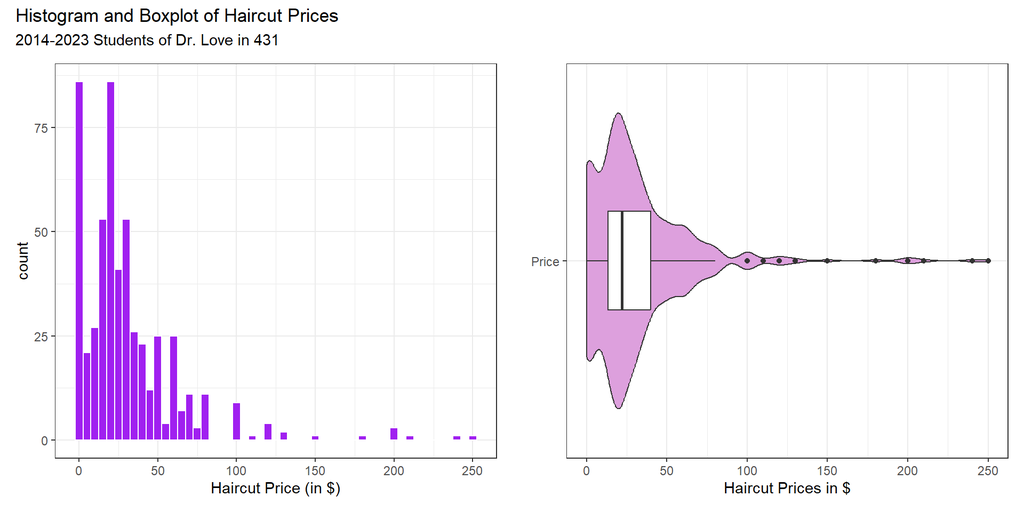

## Stem-and-Leaf of Haircut Prices

```r
stem(qsdat$haircut, scale = 2) # scale makes plot twice as long as default
```

```
  The decimal point is 1 digit(s) to the right of the |

   0 | 00000000000000000000000000000000000000000000000000000000000000000000+33
   1 | 00000000222222222222334444444445555555555555555555555555555555555555+3
   2 | 00000000000000000000000000000000000000000000000000000000000000000000+41
   3 | 00000000000000000000000000000000000000000012222222555555555555555555
   4 | 00000000000000000000035555555555588
   5 | 000000000000000000000225557
   6 | 00000000000000000000000005555555
   7 | 00000000022555
   8 | 00000000000
   9 |
  10 | 000000000
  11 | 0
  12 | 0000
  13 | 00
  14 |
  15 | 0
  16 |
  17 |
  18 | 0
  19 |
  20 | 000
  21 | 0
  22 |
  23 |
  24 | 0
  25 | 0
```

- Note this is *not* a `ggplot` so it works differently than most plots we will make this term.

## Empirical Rule Table for Haircut Prices

Let’s look across all years, as well as just in 2023

```r
mosaic::favstats(~ haircut, data = qsdat)
```

```
 min    Q1 median Q3 max     mean       sd   n missing
   0 13.25     22 40 250 30.84015 32.68273 538       9
```

```r
mosaic::favstats(~ haircut, data = qsdat |> filter(year == "2023"))
```

```
 min  Q1 median Q3 max     mean       sd  n missing
   0 7.5     30 48 200 36.95283 42.50817 53       0
```

| Range | “Normal” | 2014-2023 | 2023 |
| --- | --- | --- | --- |
| $\bar{x} \pm s$ | ~68% | $\frac{482}{538}$ = 89.6% | $\frac{48}{53}$ = 90.6% |
| $\bar{x} \pm 2\times s$ | ~95% | $\frac{514}{538}$ = 95.5% | $\frac{50}{53}$ = 94.3% |
| $\bar{x} \pm 3\times s$ | ~99.7% | $\frac{528}{538}$ = 98.1% | $\frac{51}{53}$ = 96.2% |

## How did I calculate those fractions?

```r
# haircut price mean = 30.84 and sd = 32.68 across 2014-2023

qsdat |> count(haircut >= 30.84 - 32.68 & haircut <= 30.84 + 32.68)
qsdat |> count(haircut >= 30.84 - 2*32.68 & haircut <= 30.84 + 2*32.68)
qsdat |> count(haircut >= 30.84 - 3*32.68 & haircut <= 30.84 + 3*32.68)

# haircut price mean = 36.95 and sd = 42.51 in 2023 alone

qsdat |> filter(year == "2023") |>
  count(haircut >= 36.95 - 42.51 & haircut <= 36.95 + 42.51)
qsdat |> filter(year == "2023") |>
  count(haircut >= 36.95 - 2*42.51 & haircut <= 36.95 + 2*42.51)
qsdat |> filter(year == "2023") |>
  count(haircut >= 36.95 - 3*42.51 & haircut <= 36.95 + 3*42.51)
```

# Question 4 (Heights and Haircut Prices)

## Do tall people pay less for haircuts?

Why might we think that they do, before we see the data?

- Convert our student heights from inches to centimeters…

```r
qsdat <- qsdat |> mutate(height_cm = height_in * 2.54)

qsdat |> select(student, height_in, height_cm) |> head()
```

```
# A tibble: 6 × 3
  student height_in height_cm
  <chr>       <dbl>     <dbl>
1 202301         61      155.
2 202302         63      160.
3 202303         61      155.
4 202304         64      163.
5 202305         62      157.
6 202306         73      185.
```

## Initial Numerical Summaries

```r
qsdat |> filter(complete.cases(haircut, height_cm)) |>
  summarize(n = n(), median(haircut), median(height_cm), median(height_in))
```

```
# A tibble: 1 × 4
      n `median(haircut)` `median(height_cm)` `median(height_in)`
  <int>             <dbl>               <dbl>               <dbl>
1   536                22                170.                  67
```

## A First Scatterplot

- We’ll include the straight line from a linear model, in red.

```r
dat7 <- qsdat |> filter(complete.cases(height_cm, haircut))

ggplot(dat7, aes(x = height_cm, y = haircut)) +
    geom_point(alpha = 0.3) +
    geom_smooth(method = "lm", col = "red",
                formula = y ~ x, se = TRUE) +
    labs(x = "Height (in cm)",
         y = "Price of last haircut (in $)",
         title = "Do taller people pay less for haircuts?")
```

## A First Scatterplot

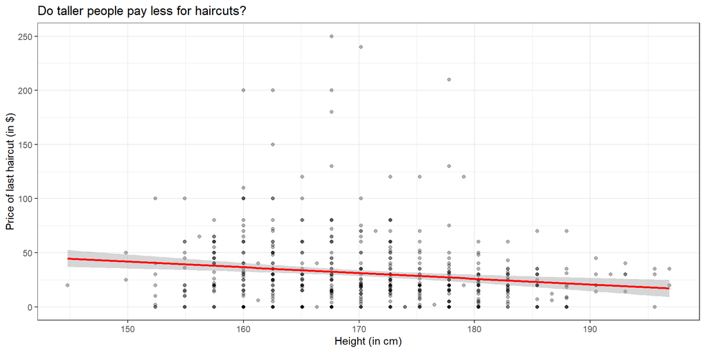

## What is the (Pearson) correlation of height and haircut price?

```r
dat7 <- qsdat |> filter(complete.cases(height_cm, haircut))

dat7 |>
    select(height_in, height_cm, haircut) |>
    cor()
```

```
           height_in  height_cm    haircut
height_in  1.0000000  1.0000000 -0.1577709
height_cm  1.0000000  1.0000000 -0.1577709
haircut   -0.1577709 -0.1577709  1.0000000
```

## What is the straight line regression model?

```r
dat7 <- qsdat |> filter(complete.cases(height_cm, haircut))

mod1 <- lm(haircut ~ height_cm, data = dat7)

mod1
```

```
Call:
lm(formula = haircut ~ height_cm, data = dat7)

Coefficients:
(Intercept)    height_cm
   121.7361      -0.5322
```

## Summarizing our model `mod1`

```r
summary(mod1)
```

```
Call:
lm(formula = haircut ~ height_cm, data = dat7)

Residuals:
    Min      1Q  Median      3Q     Max
-40.629 -19.166  -6.394   9.782 217.482

Coefficients:
            Estimate Std. Error t value Pr(>|t|)
(Intercept) 121.7361    24.6504   4.939 1.05e-06 ***
height_cm    -0.5322     0.1441  -3.692 0.000245 ***
---
Signif. codes:  0 '***' 0.001 '**' 0.01 '*' 0.05 '.' 0.1 ' ' 1

Residual standard error: 32.36 on 534 degrees of freedom
Multiple R-squared:  0.02489,   Adjusted R-squared:  0.02307
F-statistic: 13.63 on 1 and 534 DF,  p-value: 0.0002453
```

## Compare `lm` fit to `loess` smooth curve?

```r
dat7 <- qsdat |> filter(complete.cases(height_cm, haircut))

ggplot(dat7, aes(x = height_cm, y = haircut)) +
    geom_point(alpha = 0.5) +
    geom_smooth(method = "lm", col = "red",
                formula = y ~ x, se = FALSE) +
    geom_smooth(method = "loess", col = "blue",
                formula = y ~ x, se = FALSE) +
    labs(x = "Height (in cm)",
         y = "Price of last haircut (in $)",
         title = "Do taller people pay less for haircuts?")
```

- Does a linear model appear to fit these data well?
- Do taller people pay less for their haircuts?

## Compare `lm` fit to `loess` smooth curve?

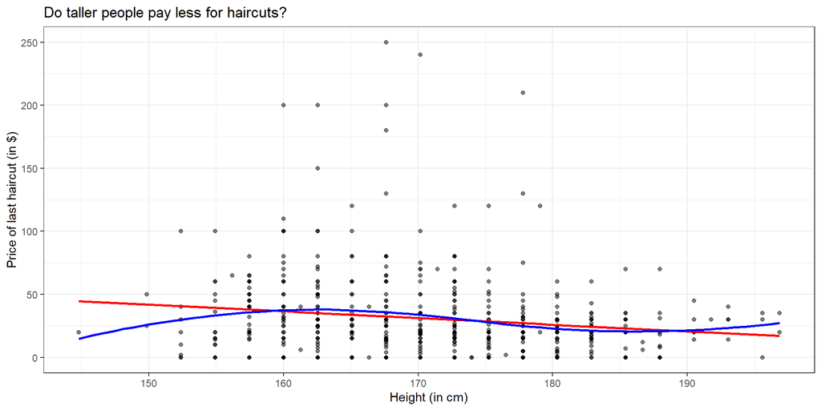

# Question 5 (Tobacco and Language Preference)

## Restrict ourselves to 2023 data

- Do students in the 2023 class have a more substantial history of tobacco use if they prefer to speak a language other than English?

```r
dat9 <- qsdat |>
    filter(year == "2023") |>
    filter(complete.cases(english, smoke)) |>
    select(student, year, english, smoke)
```

```r
summary(dat9)
```

```
   student               year    english smoke
 Length:51          2023   :51   y:37    1:47
 Class :character   2014   : 0   n:14    2: 3
 Mode  :character   2015   : 0           3: 1
                    2016   : 0
                    2017   : 0
                    2018   : 0
                    (Other): 0
```

## Tabulating the categorical variables individually

```r
dat9 |> tabyl(english)
```

```
 english  n   percent
       y 37 0.7254902
       n 14 0.2745098
```

```r
dat9 |> tabyl(smoke) |> adorn_pct_formatting()
```

```
 smoke  n percent
     1 47   92.2%
     2  3    5.9%
     3  1    2.0%
```

- What does `adorn_pct_formatting()` do?

## Cross-Classification (2 rows $\times$ 3 columns)

```r
dat9 |> tabyl(english, smoke)
```

```
 english  1 2 3
       y 34 2 1
       n 13 1 0
```

## Recode the `smoke` levels to more meaningful names in `tobacco`

```r
dat9 <- dat9 |>
    mutate(tobacco = fct_recode(smoke,
            "Never" = "1", "Quit" = "2", "Current" = "3"))
```

### Check our work?

```r
dat9 |> count(smoke, tobacco)
```

```
# A tibble: 3 × 3
  smoke tobacco     n
  <fct> <fct>   <int>
1 1     Never      47
2 2     Quit        3
3 3     Current     1
```

- Everyone with `smoke` = 1 has `tobacco` as Never, etc.

## Restate the cross-tabulation

Now we’ll use this new variable, and this time, add row and column totals.

```r
dat9 |> tabyl(english, tobacco) |>
    adorn_totals(where = c("row", "col"))
```

```
 english Never Quit Current Total
       y    34    2       1    37
       n    13    1       0    14
   Total    47    3       1    51
```

- What can we conclude about this association?

## How about in 2014-2023?

```r
dat8 <- qsdat |>
  filter(complete.cases(english, smoke)) |>
  mutate(tobacco = fct_recode(smoke,
            "Never" = "1", "Quit" = "2", "Current" = "3"))

dat8 |>
  tabyl(english, tobacco) |>
  adorn_totals(where = c("row", "col"))
```

```
 english Never Quit Current Total
       y   393   28       5   426
       n   108    3       4   115
   Total   501   31       9   541
```

- Now, what is your conclusion?

## Next Time

Analyzing a (small) health dataset

## Cleaning up the temporary objects

```r
rm(mod1,
   p4, p5, p6a, p6b,
   dat1, dat2, dat3, dat4, dat5, dat6, dat7, dat8, dat9
   )

## this just leaves
## qsdat and quicksur_raw in my Global Environment
```

431 Class 03 | 2023-09-05 | https://thomaselove.github.io/431-2023/